# 19_08_2024_S_van_Mesdag_Warton_and_Hodbarrow_CCAs

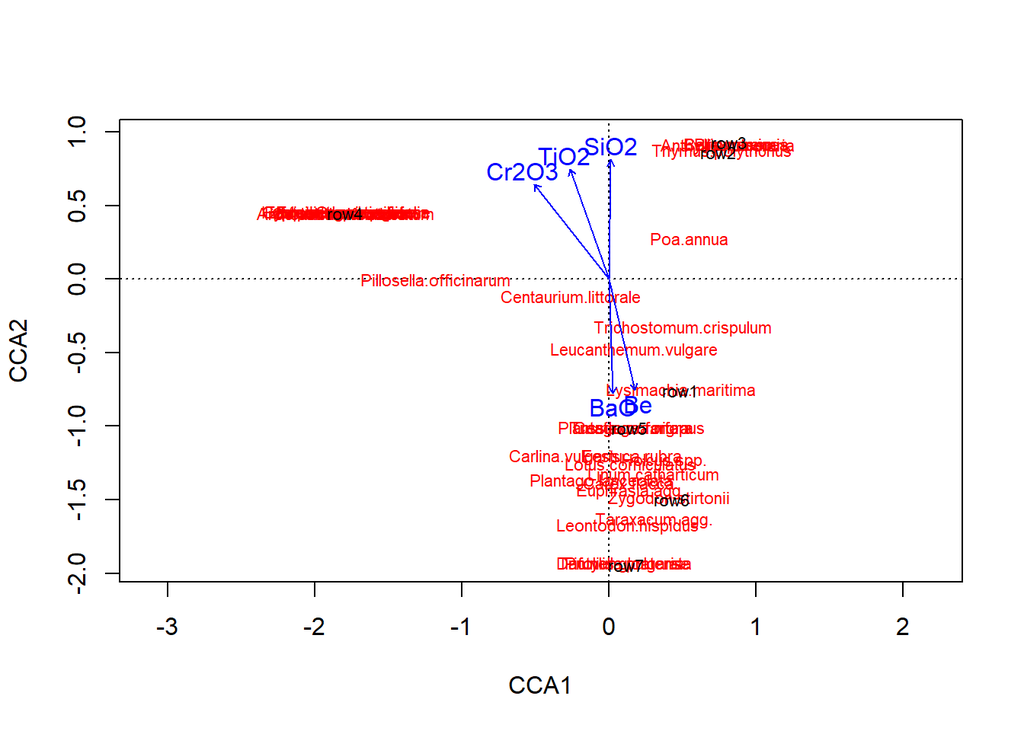

```r
plot(HodbarrowCCA13)
```

```r
anova(HodbarrowCCA13)
```

```
## Set of permutations < 'minperm'. Generating entire set.
```

```
## Permutation test for cca under reduced model
## Permutation: free
## Number of permutations: 5039
##
## Model: cca(formula = HodbarrowPS ~ Cr2O3 + Be + BaO + SiO2 + TiO2, data = HodbarrowPC)
##          Df ChiSquare      F Pr(>F)
## Model     5   2.72222 6.1483  0.001 ***
## Residual  1   0.08855
## ---
## Signif. codes:  0 '***' 0.001 '**' 0.01 '*' 0.05 '.' 0.1 ' ' 1
```

#High F statistic of 6.1483 and p value of 0.001.

```r
HodbarrowCCA14 <- cca(HodbarrowPS ~ Cr2O3 + SiO2 + BaO + Zn + TiO2,
                      data = HodbarrowPC)

print(HodbarrowCCA14)
```

```
## Call: cca(formula = HodbarrowPS ~ Cr2O3 + SiO2 + BaO + Zn + TiO2, data
## = HodbarrowPC)
##
##               Inertia Proportion Rank
## Total         2.81078    1.00000
## Constrained   2.63479    0.93739    5
## Unconstrained 0.17598    0.06261    1
## Inertia is scaled Chi-square
## 106 species (variables) deleted due to missingness
##
## Eigenvalues for constrained axes:
##   CCA1   CCA2   CCA3   CCA4   CCA5
## 0.9045 0.7532 0.4861 0.2961 0.1949
##
## Eigenvalues for unconstrained axes:
##     CA1
## 0.17598
```

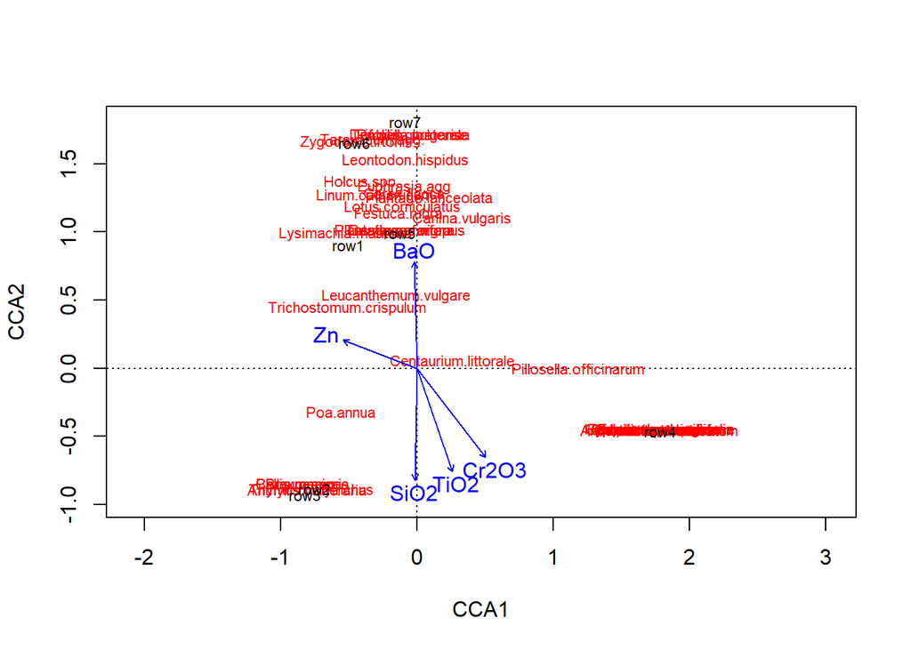

```r
plot(HodbarrowCCA14)
```

```r
anova(HodbarrowCCA14)
```

```
## Set of permutations < 'minperm'. Generating entire set.
```

```
## Permutation test for cca under reduced model
## Permutation: free
## Number of permutations: 5039
##
## Model: cca(formula = HodbarrowPS ~ Cr2O3 + SiO2 + BaO + Zn + TiO2, data = HodbarrowPC)
##          Df ChiSquare      F Pr(>F)
## Model     5   2.63479 2.9944  0.006 **
## Residual  1   0.17598
## ---
## Signif. codes:  0 '***' 0.001 '**' 0.01 '*' 0.05 '.' 0.1 ' ' 1
```

#High F statistic of 2.9944 and p value of 0.006.

```r
HodbarrowCCA15 <- cca(HodbarrowPS ~ Cr2O3 + SiO2 + BaO + TiO2 + pH,
                      data = HodbarrowPC)

print(HodbarrowCCA15)
```

```
## Call: cca(formula = HodbarrowPS ~ Cr2O3 + SiO2 + BaO + TiO2 + pH, data
## = HodbarrowPC)
##
##               Inertia Proportion Rank
## Total          2.8108     1.0000
## Constrained    2.5082     0.8924    5
## Unconstrained  0.3026     0.1076    1
## Inertia is scaled Chi-square
## 106 species (variables) deleted due to missingness
##
## Eigenvalues for constrained axes:
##   CCA1   CCA2   CCA3   CCA4   CCA5
## 0.9035 0.7506 0.3828 0.2748 0.1965
##
## Eigenvalues for unconstrained axes:
##     CA1
## 0.30257
```

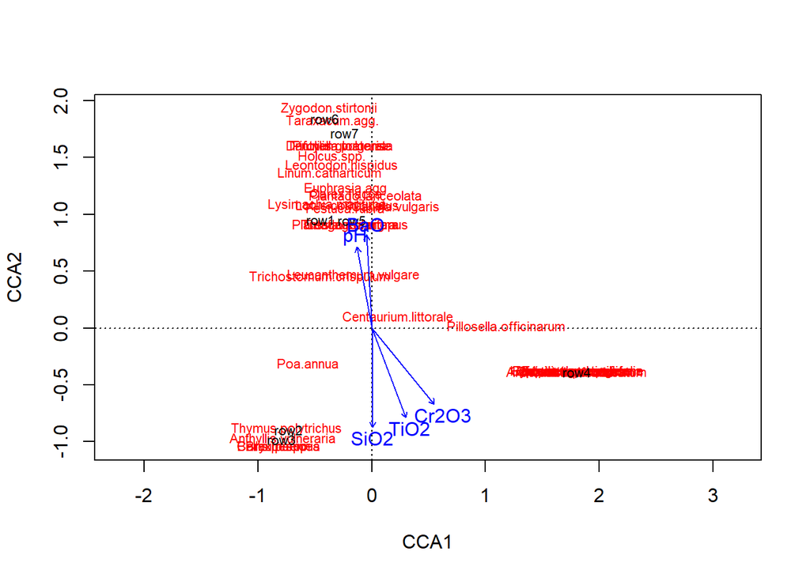

```r
plot(HodbarrowCCA15)
```

```r
anova(HodbarrowCCA15)
```

```
## Set of permutations < 'minperm'. Generating entire set.
```

```
## Permutation test for cca under reduced model
## Permutation: free
## Number of permutations: 5039
##
## Model: cca(formula = HodbarrowPS ~ Cr2O3 + SiO2 + BaO + TiO2 + pH, data = HodbarrowPC)
##          Df ChiSquare      F Pr(>F)
## Model     5   2.50821 1.6579  0.053 .
## Residual  1   0.30257
## ---
## Signif. codes:  0 '***' 0.001 '**' 0.01 '*' 0.05 '.' 0.1 ' ' 1
```

```r
HodbarrowCCA16 <- cca(HodbarrowPS ~ Cr2O3 + SiO2 + Be + TiO2 + pH,
                      data = HodbarrowPC)

print(HodbarrowCCA16)
```

```
## Call: cca(formula = HodbarrowPS ~ Cr2O3 + SiO2 + Be + TiO2 + pH, data =
## HodbarrowPC)
##
##               Inertia Proportion Rank
## Total          2.8108     1.0000
## Constrained    2.5183     0.8959    5
## Unconstrained  0.2925     0.1041    1
## Inertia is scaled Chi-square
## 106 species (variables) deleted due to missingness
##
## Eigenvalues for constrained axes:
##   CCA1   CCA2   CCA3   CCA4   CCA5
## 0.9050 0.7591 0.4787 0.2668 0.1087
##
## Eigenvalues for unconstrained axes:
##     CA1
## 0.29251
```

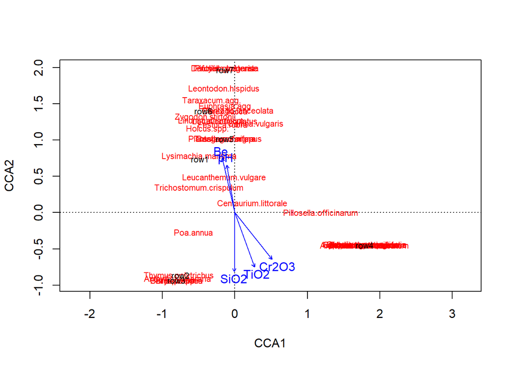

```r
plot(HodbarrowCCA16)
```

```r
anova(HodbarrowCCA16)
```

```
## Set of permutations < 'minperm'. Generating entire set.
```

```
## Permutation test for cca under reduced model
## Permutation: free
## Number of permutations: 5039
##
## Model: cca(formula = HodbarrowPS ~ Cr2O3 + SiO2 + Be + TiO2 + pH, data = HodbarrowPC)
##          Df ChiSquare      F Pr(>F)
## Model     5   2.51827 1.7218  0.041 *
## Residual  1   0.29251
## ---
## Signif. codes:  0 '***' 0.001 '**' 0.01 '*' 0.05 '.' 0.1 ' ' 1
```

```r
HodbarrowCCA17 <- cca(HodbarrowPS ~ Na2O + SiO2 + Be + BaO + TiO2,
                      data = HodbarrowPC)

print(HodbarrowCCA17)
```

```
## Call: cca(formula = HodbarrowPS ~ Na2O + SiO2 + Be + BaO + TiO2, data =
## HodbarrowPC)
##
##               Inertia Proportion Rank
## Total         2.81078    1.00000
## Constrained   2.70680    0.96301    5
## Unconstrained 0.10397    0.03699    1
## Inertia is scaled Chi-square
## 106 species (variables) deleted due to missingness
##
## Eigenvalues for constrained axes:
##   CCA1   CCA2   CCA3   CCA4   CCA5
## 0.8977 0.7589 0.5140 0.3406 0.1955
##
## Eigenvalues for unconstrained axes:
##     CA1
## 0.10397
```

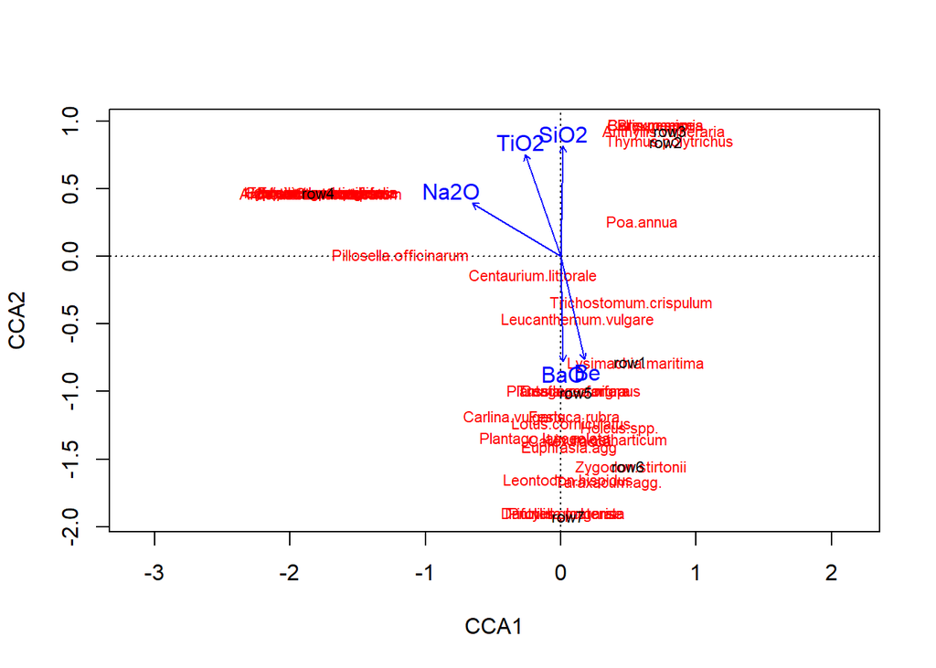

```r
plot(HodbarrowCCA17)
```

```r
anova(HodbarrowCCA17)
```

```
## Set of permutations < 'minperm'. Generating entire set.
```

```
## Permutation test for cca under reduced model
## Permutation: free
## Number of permutations: 5039
##
## Model: cca(formula = HodbarrowPS ~ Na2O + SiO2 + Be + BaO + TiO2, data = HodbarrowPC)
##          Df ChiSquare      F Pr(>F)
## Model     5   2.70680 5.2067  0.001 ***
## Residual  1   0.10397
## ---
## Signif. codes:  0 '***' 0.001 '**' 0.01 '*' 0.05 '.' 0.1 ' ' 1
```

#After doing a few more CCAs, the one with the highest F statistic by far (6.1483) is #HodbarrowCCA13. The p value of this one is also low, at 0.001. #The plot for this CCA looks OK, but it can be modified to make it easier #to interpret what is going on with some of the different plant species and communities.

```r
options(max.print=1000000)

HodbarrowCCA13$CCA$v
```

```
##                              CCA1         CCA2         CCA3       CCA4
## Anthoxanthum.odoratum  -1.8808682  0.515930843 -0.144904225 -0.1398460
## Anthyllis.vulneraria    0.8513919  1.041042224  0.226654799 -0.5136023
## Bellis.perennis         0.9116973  1.047100739  0.187480527 -0.7875399
## Bryum.spp.              0.9116973  1.047100739  0.187480527 -0.7875399
## Campanula.rotundifolia -1.8808682  0.515930843 -0.144904225 -0.1398460
## Carex.flacca            0.1419301 -1.586688931  1.350916103  0.1033922
## Carex.panicea           0.9116973  1.047100739  0.187480527 -0.7875399
## Carlina.vulgaris       -0.3164334 -1.387531027  0.971548823 -1.3666677
## Centaurea.nigra         0.1630491 -1.163737359  0.694471519  1.7013144
## Centaurium.littorale   -0.2745504 -0.134095913  0.468430358  0.4684153
## Cerastium.fontanum     -1.8808682  0.515930843 -0.144904225 -0.1398460
## Dactylis.glomerata      0.1102516 -2.221116290  2.335582980 -2.2934911
## Equisetum.arvense      -1.8808682  0.515930843 -0.144904225 -0.1398460
## Equisteum.variegatum   -1.8808682  0.515930843 -0.144904225 -0.1398460
## Euphrasia.agg           0.1386204 -1.652972387  1.453791747 -0.1470284
## Festuca.rubra           0.1705365 -1.375764205  0.923216137  0.3245228
## Holcus.spp.             0.3971040 -1.412117935 -2.719427123 -1.1910307
## Holcus.lanatus         -1.8808682  0.515930843 -0.144904225 -0.1398460
## Hypnum.cupressiforme   -1.8808682  0.515930843 -0.144904225 -0.1398460
## Leontodon.hispidus      0.1346201 -1.927026434  1.675332121 -1.3244222
## Leucanthemum.vulgare    0.1775724 -0.555027518 -0.004501243  1.3982298
## Linum.catharticum       0.3192237 -1.513567295 -0.844415940 -2.6519716
## Lotus.corniculatus      0.1493355 -1.438381237  1.120734236  0.6637026
## Lysimachia.maritima     0.5162381 -0.866505432 -2.223199809  3.4437837
## Medicago.lupulina      -1.8808682  0.515930843 -0.144904225 -0.1398460
## Ononis.repens          -1.7150902  0.513540930 -0.107948056 -0.0989720
## Pillosella.officinarum -1.2406638 -0.001280767  0.071603827  0.4584307
## Plantago.coronopus      0.1630491 -1.163737359  0.694471519  1.7013144
## Plantago.lanceolata    -0.0545567 -1.576064174  1.498089179 -0.6145219
## Poa.annua               0.5789231  0.322731125  0.410337564  0.4290675
## Prunella.vulgaris       0.1102516 -2.221116290  2.335582980 -2.2934911
## Taraxacum.agg.          0.3241573 -1.880643518 -2.336923359 -3.8947193
## Thymus.polytrichus      0.8033777  0.996376956  0.181773550 -0.3850685
## Trichostomum.crispulum  0.5297032 -0.380228576 -0.850468946  1.9199615
## Trifolium.pratense      0.1102516 -2.221116290  2.335582980 -2.2934911
## Tussilago.farfara       0.1630491 -1.163737359  0.694471519  1.7013144
## Zygodon.stirtonii       0.4311102 -1.710407131 -4.673176528 -4.6953334
##                               CCA5
## Anthoxanthum.odoratum  -0.23832396
```

[output cut: 130 more lines]

[output not shown]

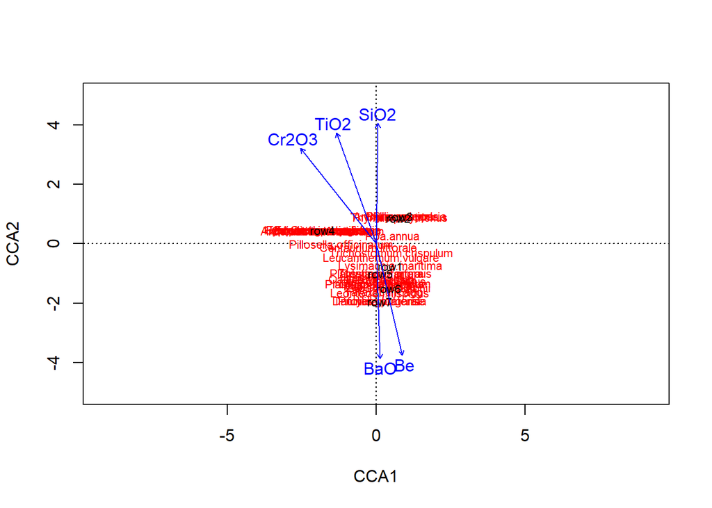

```r
#The "v values" show the positions of individual species on the graph, with the CCA1 value
#representing the x axis and the CCA2 value representing the y axis, in the case of the
#graph created in R.

plot(HodbarrowCCA13, xlim = c(-5, 5), ylim = c(-5, 5))
```

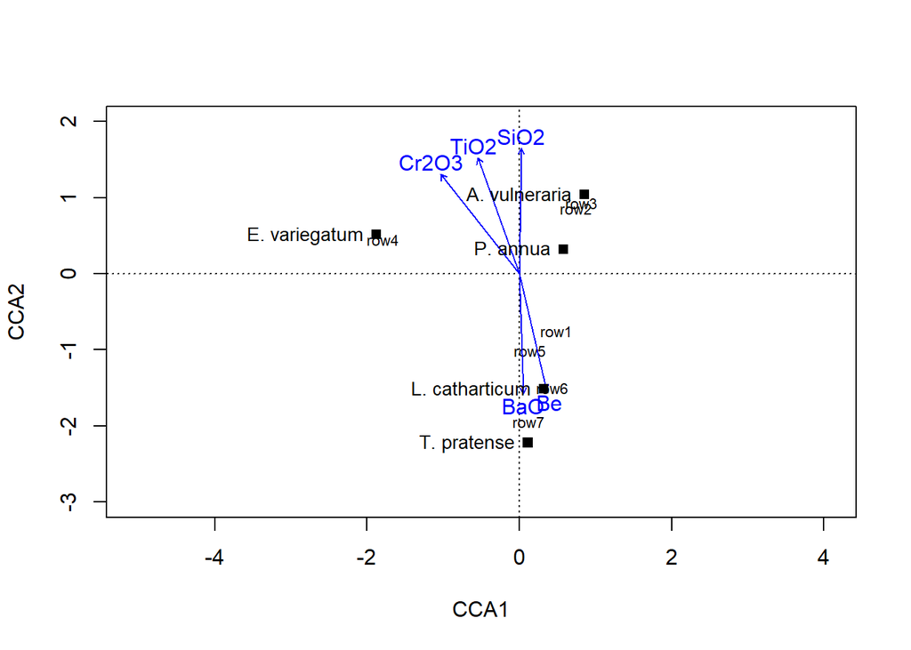

```r
#Increasing the xlim and ylim to give more room for writing on graph

plot(HodbarrowCCA13, choices = c(1,2), display = c("wa", "bp"), xlim = c(-4, 3),
     ylim = c(-3, 2))

#Increasing the xlim and ylim to give more room for writing on graph Note that Community
#2 and Community 3 are grouped/clustered together in this CCA plot and that Communities
#1, 5, 6 and 7 are grouped together.

points(x = -1.8808682 , y = 0.515930843, pch = 15, col = "black")

#This point represents Equisetum variegatum

text('E. variegatum', x = -1.8808682, y = 0.515930843, cex = 0.88, pos = 2, col = "black")

#Adding text to this point.

points(x = 0.5789231 , y = 0.322731125, pch = 15, col = "black")

#This point represents Poa annua

text('P. annua', x = 0.5789231 , y = 0.322731125, cex = 0.88, pos = 2, col = "black")

#Adding text to this point

points(x = 0.1102516, y = -2.221116290, pch = 15, col = "black")

#This point represents Trifolium pratense

text('T. pratense', x = 0.1102516, y = -2.221116290, cex = 0.88, pos = 2, col = "black")

#Adding text to this point

points(x = 0.3192237, y = -1.513567295, pch = 15, col = "black")

#This point represents Linum catharticum

text('L. catharticum', x = 0.3192237, y = -1.513567295, cex = 0.88, pos = 2, col = "black")

#Adding text to this point

points(x = 0.8513919, y = 1.041042224, pch = 15, col = "black")

#This point represents Anthyllis vulneraria

text('A. vulneraria', x = 0.8513919, y = 1.041042224, cex = 0.88, pos = 2, col = "black")
```

```r
#Adding text to this point
```